# Course Project Part 1

Joe Eldredge | jwe2n@virginia.edu

October 12, 2020

I am inheriting many formulas in this workbook SYS 6018 tidylab.rmd files, from live session (live.rmd) files provided for the course, as well as from general resource documentation provided by RStudio in https://rstudio.com/resources/cheatsheets/. I will annotate the code throughout to indicate that I have not repurposed the formula without understanding. All other programming is my own, unless cited.

I am using the functions from the following packages for this assignment, most of which have been discussed or used in the course already:

```r
#install.packages("reactable")
#I use reactable functions described here: https://glin.github.io/reactable/articles/examples.html#filtering
#install.packages("caTools")

library(caTools)
library(tidyverse)
library(reactable)
library(broom)
library(forcats)
library(caret)
library(stats)
library(car)
library(ggplot2)
library(plotly)
library(leaps)
library(gridExtra)
```

# Project Goals

Following 2010 Haiti Earthquake [link](https://en.wikipedia.org/wiki/2010_Haiti_earthquake) “it was known that the people whose homes had been destroyed by the earthquake were creating temporary shelters using blue tarps, and these blue tarps would be good indicators of where the displaced persons were – if only they could be located in time, out of the thousands of images that would be collected every day. The problem was that there was no way for aid workers to search the thousands of images in time to find the tarps and communicate the locations back to the rescue workers on the ground in time. The solution would be provided by data-mining algorithms, which could search the images far faster and more thoroughly (and accurately?) then humanly possible. The goal was to find an algorithm that could effectively search the images in order to locate displaced persons and communicate those locations rescue workers so they could help those who needed it in time.”

The goal of this project is therefore to “Use data from the actual data collection process was carried out over Haiti” and “test each of the algorithms you learn in this course on the imagery data collected during the relief efforts made Haiti in response to the 2010 earthquake, and determine which method you will use to as accurately as possible, and in as timely a manner as possible, locate as many of the displaced persons identified in the imagery data so that they can be provided food and water before their situations become unsurvivable.”

# Objective: Use Modeling Techniques with K-Folds and Test Results Against Various Thresholds

1. provide a thresholds used
2. explain and justify rationale

[output not shown]

# Step 0. Interpret the Problem Statement

In this classification problem, people’s lives are at stake. I want tests to be as accurate as possible and I want the relief delivery to be as efficient as possible. The latter part of that statement is important, because if time were no object, I could err on the side of delivering all of the resources (which are probably also finite) to everyone whether they needed them or not. But that isn’t the case.

In other words, in addition to high recall, I also need to look at specificity to some degree. So this becomes a threshold problem where I am focused on both accuracy (true blue tarps divided by population) and precision (reducing false discovery; non-blue tarps). Looking at this tradeoff in terms of finding a meaningful diagnostic or score will be the way I will approach setting my threshold in Step 7.

### Assumptions and Other Thoughts

I am making a few assumptions in this analysis. The first is that I have independent and identically distributed error terms in the data. We’re using a dataset which sheds limited light on the methods of data collection other than it is high-resolution geo-referenced imagery. So I also need to assume the imagery data is very reliable in terms of how it has read the pixels and created unique and uniquely indexed plots. Another is that I don’t know the distributions of the data well enough to decide on one parametric estimation technique.

# Step 1. Look at the data

I used the “reactable” package to apply some sorting and aggregation.

```r
haiti<-read.csv('HaitiPixels.csv',header=TRUE,sep=",")
dim(haiti)
```

```
#> [1] 63241     4
```

```r
sapply(haiti, function(x) sum(is.na(x)))
```

```
#> Class   Red Green  Blue
#>     0     0     0     0
```

```r
#https://glin.github.io/reactable/articles/examples.html#multiple-groups-1
reactable(haiti,  groupBy = "Class",  columns = list(
    Red = colDef(aggregate = "mean"), Green = colDef(aggregate = "mean"),Blue = colDef(aggregate = "mean")))
```

| Class | Red | Green | Blue |
| --- | --- | --- | --- |
| Vegetation | 64 | 67 | 50 |
| Vegetation | 64 | 67 | 50 |
| Vegetation | 64 | 66 | 49 |
| Vegetation | 75 | 82 | 53 |
| Vegetation | 74 | 82 | 54 |
| Vegetation | 72 | 76 | 52 |
| Vegetation | 71 | 72 | 51 |
| Vegetation | 69 | 70 | 49 |
| Vegetation | 68 | 70 | 49 |
| Vegetation | 67 | 70 | 50 |

[output cut: 63231 more lines]

```r
2022/63241 #percentages of blue tarps
```

```
#> [1] 0.03197293
```

I can see from the results that: * There are no missing records or N/A values in the set. * There are 4,744 “Various Non-Tarp” and 9,903 rooftops that will create a challenge because of how close the red and green values are to the respective values for blue tarps. * There aren’t many images classified as blue tarps. 2,022 out of ~63,200 or ~3.2%. Thinking about this critically, this is a more limited dataset than I want to be working with when it comes time for cross-validation using test/train sets. Therefore, a high k-folds (10) seems appropriate to reduce sampling variablility. * The Blue value for blue is *DISTINCTLY HIGHER* for blue tarp than other classes. This makes sense, but is it enough to think about dropping the red and green features from the model? As we will show, probably not.

# Step 2. Create a hold out dataset

```r
set.seed(2) #set random seed
haiti <- tibble::rowid_to_column(haiti, "ID") %>% mutate(binary=ifelse(Class=="Blue Tarp","Blue.Tarp","NonTarp"))
haiti$binary<-as.factor(haiti$binary)
table(binary)
```

[output not shown]

```r
contrasts(binary) #understand my reference class is blue tarp using this new variable. So blue tarp = 0 in a prediction scenario - VERY IMPORTANT!!
```

[output not shown]

```r
haiti_holdout <- dplyr::slice_sample(haiti, prop=0.2) #I am keeping 80% of data in the dataset because I want really good training, but I want enough to have a couple hundred blue tarps in the test set.
haiti.train <- haiti[-haiti_holdout$ID,]
```

```r
#reactable(haiti.train,  groupBy = "Class",  columns = list(
#   Red = colDef(aggregate = "mean"), Green = colDef(aggregate = "mean"),Blue = colDef(aggregate = "mean")))
```

I used the code chunk above to make sure my training set was pretty reflective of the original set. It was.

# Step 3. Select a Subset of Predictors

In this step, I am going to examine the base model and also try to confirm that I cannot get rid of any predictors

Is there multicollinearity in the basic model that looks at red, green and blue?

```r
basicmod<-glm(binary~Red+Blue+Green,data=haiti,family=binomial)
vif(basicmod)
```

```
#>      Red     Blue    Green
#> 224.0059 371.0834 259.5066
```

```r
pairs(haiti[,-c(binary)])
```

[output not shown]

Of course. These values are derived as complements to each other, to describe/replicate the color of the images. Given the array of images I’m dealing with, do I need all three of them? Do they tell me different information in combination? I should explore this by looking at the interaction between variables.

```r
mod2<-glm(binary~(Red+Green+Blue)^2,data=haiti,family=binomial)
mod2.summary <- mod2 %>% broom::tidy()
mod2.summary
```

```
#> # A tibble: 7 x 5
#>   term         estimate std.error statistic  p.value
#>   <chr>           <dbl>     <dbl>     <dbl>    <dbl>
#> 1 (Intercept) 11.5       0.886        13.0  1.16e-38
#> 2 Red         -0.0564    0.0368       -1.53 1.25e- 1
#> 3 Green        0.190     0.0502        3.79 1.52e- 4
#> 4 Blue        -0.291     0.0459       -6.33 2.38e-10
#> 5 Red:Green    0.00111   0.000358      3.11 1.85e- 3
#> 6 Red:Blue     0.000620  0.000334      1.86 6.33e- 2
#> 7 Green:Blue  -0.00125   0.000233     -5.37 7.75e- 8
```

```r
summary(mod2) #base r summary shows p-values with significance levels
```

```
#>
#> Call:
#> glm(formula = binary ~ (Red + Green + Blue)^2, family = binomial,
#>     data = haiti)
#>
#> Deviance Residuals:
#>     Min       1Q   Median       3Q      Max
#> -2.9738   0.0000   0.0071   0.0271   3.3660
#>
#> Coefficients:
#>               Estimate Std. Error z value Pr(>|z|)
#> (Intercept) 11.5159473  0.8855839  13.004  < 2e-16 ***
#> Red         -0.0563910  0.0367597  -1.534 0.125018
#> Green        0.1903153  0.0502490   3.787 0.000152 ***
#> Blue        -0.2910610  0.0459461  -6.335 2.38e-10 ***
#> Red:Green    0.0011138  0.0003577   3.114 0.001845 **
#> Red:Blue     0.0006199  0.0003338   1.857 0.063287 .
#> Green:Blue  -0.0012540  0.0002334  -5.373 7.75e-08 ***
#> ---
#> Signif. codes:  0 '***' 0.001 '**' 0.01 '*' 0.05 '.' 0.1 ' ' 1
#>
#> (Dispersion parameter for binomial family taken to be 1)
#>
#>     Null deviance: 17901.6  on 63240  degrees of freedom
#> Residual deviance:  1327.7  on 63234  degrees of freedom
#> AIC: 1341.7
#>
#> Number of Fisher Scoring iterations: 13
```

It seems like I can probably get rid of Red and the interaction between Red and Blue. I will use this as the starting point to a regsubsets selection below.

```r
regfit.full <- regsubsets(binary~(Green+Blue+Red*Green+Green*Blue), data=haiti)
reg.summary <- regfit.full %>% broom::tidy()
reg.summary %>% dplyr::select(r.squared)
```

```
#> # A tibble: 5 x 1
#>   r.squared
#>       <dbl>
#> 1    0.0559
#> 2    0.412
#> 3    0.445
#> 4    0.465
#> 5    0.465
```

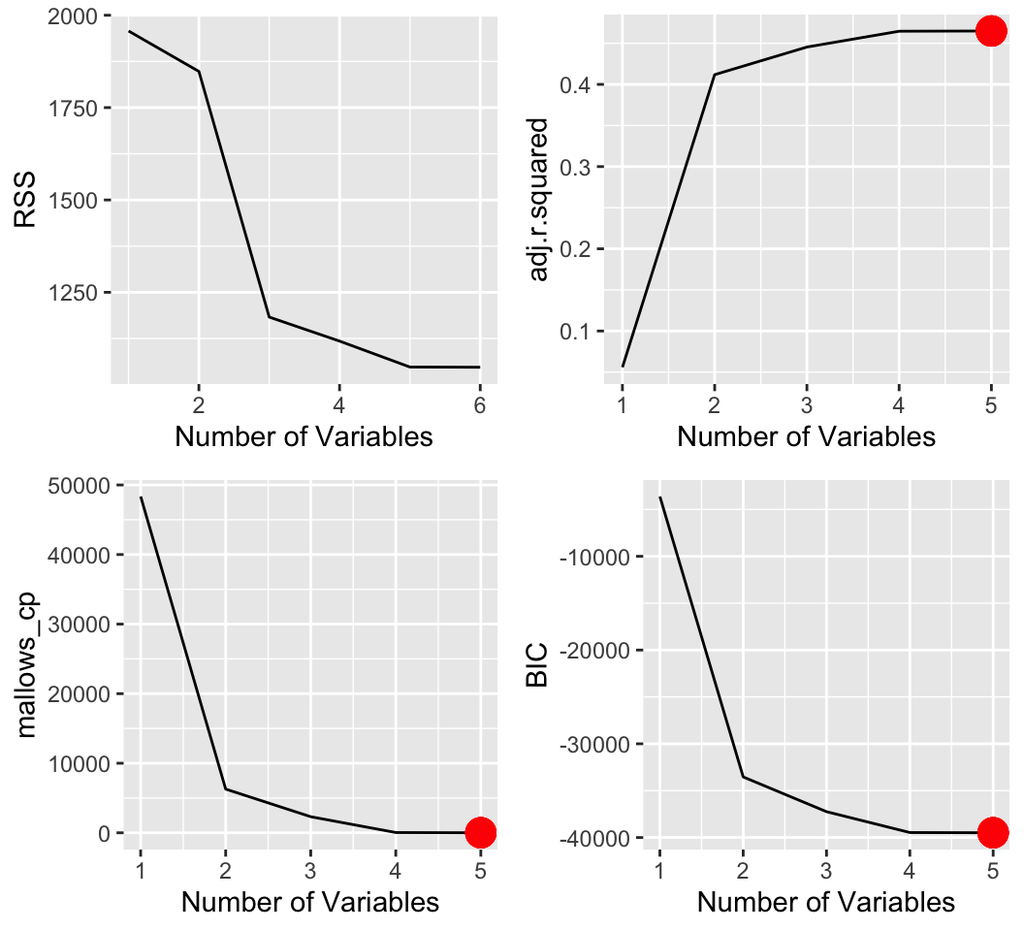

```r
RSSs <- tibble(RSS=regfit.full$rss) %>%
  ggplot(aes(x=seq_along(RSS), y=RSS)) + geom_line() +
  xlab("Number of Variables")

adjR2s <- reg.summary %>%
  ggplot(aes(x=seq_along(adj.r.squared), y=adj.r.squared)) + geom_line() +
  geom_point(reg.summary, color='red', size=5,
             mapping=aes(x=which.max(adj.r.squared), y=max(adj.r.squared))) +
  xlab("Number of Variables")

mallows_cps <- reg.summary %>%
  ggplot(aes(x=seq_along(mallows_cp), y=mallows_cp)) + geom_line() +
  geom_point(reg.summary, color='red', size=5,
             mapping=aes(x=which.min(mallows_cp), y=min(mallows_cp))) +
  xlab("Number of Variables")

BICs <- reg.summary %>%
  ggplot(aes(x=seq_along(BIC), y=BIC)) + geom_line() +
  geom_point(reg.summary, color='red', size=5,
             mapping=aes(x=which.min(BIC), y=min(BIC))) +
  xlab("Number of Variables")

grid.arrange(RSSs, adjR2s, mallows_cps, BICs, nrow=2) #3 degree model
```

```r
coef(regfit.full,4)
```

```
#>   (Intercept)          Blue           Red     Green:Red    Green:Blue
#>  2.176947e+00 -1.450118e-02  8.241326e-03 -2.429649e-05  4.282234e-05
```

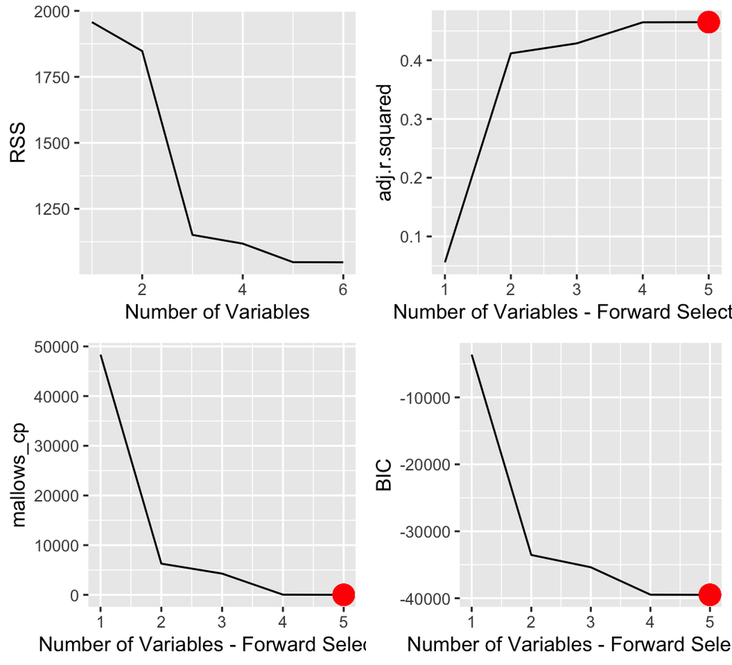

```r
#Forward Selection
regfit.fwd <- regsubsets(binary~Green+Blue+Red*Green+Green*Blue,data=haiti, method="forward")
RSSsForward <- tibble(RSS=regfit.fwd$rss) %>% #residual sum of squares - pick lowest
  ggplot(aes(x=seq_along(RSS), y=RSS)) + geom_line() +
  xlab("Number of Variables")

regfit.fwd <- regfit.fwd %>% broom::tidy()
adjR2sForward <- regfit.fwd %>%
  ggplot(aes(x=seq_along(adj.r.squared), y=adj.r.squared)) + geom_line() +
  geom_point(regfit.fwd, color='red', size=5,
             mapping=aes(x=which.max(adj.r.squared), y=max(adj.r.squared))) +
  xlab("Number of Variables - Forward Selection")

mallows_cpsForward <- regfit.fwd %>%
  ggplot(aes(x=seq_along(mallows_cp), y=mallows_cp)) + geom_line() +
  geom_point(regfit.fwd, color='red', size=5,
             mapping=aes(x=which.min(mallows_cp), y=min(mallows_cp))) +
  xlab("Number of Variables - Forward Selection")

BICsForward <- regfit.fwd %>%
  ggplot(aes(x=seq_along(BIC), y=BIC)) + geom_line() +
  geom_point(regfit.fwd, color='red', size=5,
             mapping=aes(x=which.min(BIC), y=min(BIC))) +
  xlab("Number of Variables - Forward Selection")

grid.arrange(RSSsForward, adjR2sForward, mallows_cpsForward, BICsForward, nrow=2)
```

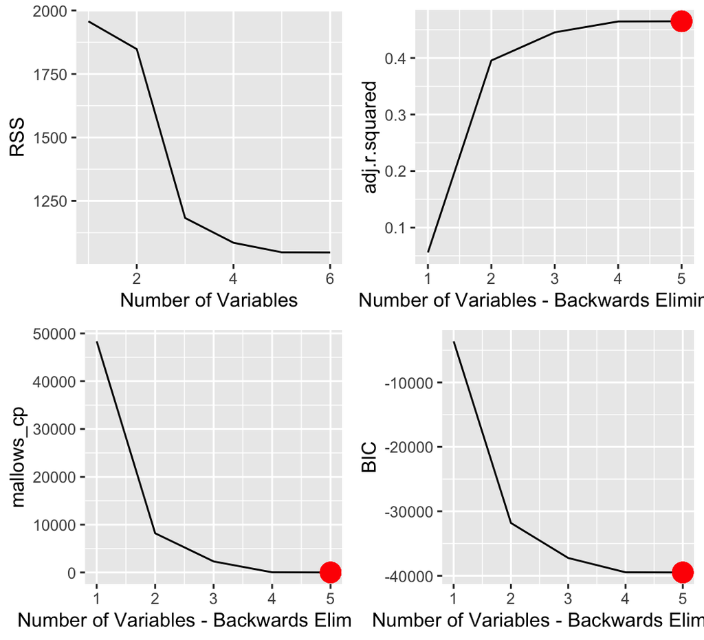

```r
#Backwards Elimination
regfit.bwd <- regsubsets(binary~(Green+Blue+Red*Green+Green*Blue), data=haiti, method="backward")
RSSsBackwards <- tibble(RSS=regfit.bwd$rss) %>%  #residual sum of squares - pick lowest
  ggplot(aes(x=seq_along(RSS), y=RSS)) + geom_line() +
  xlab("Number of Variables")

regfit.bwd <- regfit.bwd %>% broom::tidy()

adjR2sBackwards <- regfit.bwd %>%
  ggplot(aes(x=seq_along(adj.r.squared), y=adj.r.squared)) + geom_line() +
  geom_point(regfit.bwd, color='red', size=5,
             mapping=aes(x=which.max(adj.r.squared), y=max(adj.r.squared))) +
  xlab("Number of Variables - Backwards Elimination")

mallows_cpsBackwards <- regfit.bwd %>%
  ggplot(aes(x=seq_along(mallows_cp), y=mallows_cp)) + geom_line() +
  geom_point(regfit.bwd, color='red', size=5,
             mapping=aes(x=which.min(mallows_cp), y=min(mallows_cp))) +
  xlab("Number of Variables - Backwards Elimination")

BICsBackwards <- regfit.bwd %>%
  ggplot(aes(x=seq_along(BIC), y=BIC)) + geom_line() +
  geom_point(regfit.bwd, color='red', size=5,
             mapping=aes(x=which.min(BIC), y=min(BIC))) +
  xlab("Number of Variables - Backwards Elimination")

grid.arrange(RSSsBackwards, adjR2sBackwards, mallows_cpsBackwards, BICsBackwards, nrow=2)
```

# Step 4. Validate Subset Selection Using Regularization

The results from my “selection methods” should be taken with a grain of salt. They have not been improved by using ridge/lasso with a training dataset and k-folds. I will try this method below.

```r
set.seed(9)

# https://www.datacareer.ch/blog/ridge-and-lasso-in-r/
ridgeCV <- caret::train(binary~Green+Blue+Red*Green+Green*Blue, data=haiti.train,
                        method="glmnet",
             tuneGrid=data.frame(alpha=rep(0,100), #for alpha = 0 to 100
                                 lambda=10^seq(4,0,length=100)), #select 100 values of lambda from 10^4 to 10^0
             trControl=trainControl("cv", number=10, returnResamp='all')) #k=5 folds cross validation
coef(ridgeCV$finalModel, ridgeCV$bestTune$lambda) %>% length() #it has all coefficients
```

```
#> [1] 6
```

```r
lassoCV1 <- caret::train(binary~Green+Blue+Red*Green+Green*Blue, data=haiti.train,
                        method="glmnet",
             tuneGrid=data.frame(alpha=rep(1,100),
                                 lambda=10^seq(4,-2,length=100)),
             trControl=trainControl("cv", number=10, returnResamp='all'))
coef(lassoCV1$finalModel, lassoCV1$bestTune$lambda) %>% length() #it has all coefficients
```

```
#> [1] 6
```

# Step 5. Create Initial Confusion Matrices to Validate Subset Chosen

Before approaching the more specific challenge about which statistical modeling technique is most accurate, I want to try and develop a sense of where to begin in applying the thresholds. I already know what I want out of the model (high recall and relatively high specificity), but I would like to quickly visualize the likelihood for false positives and negatives using a few models.

## Need to Set KNN “k” first

For the k-nearest neighbors (knn) method, I need to first find a good value for k. I can try different models out with a varying number of nearest neighbors.

```r
set.seed(10)
classifier <- caret::train(binary~Green+Blue+Red*Green+Green*Blue, data=haiti, method="knn",
              preProcess=c("center","scale"),
              tuneGrid=data.frame(k=seq(15,30,1)),
              trControl = caret::trainControl("cv", number=10,
                          returnResamp='all', savePredictions='final',
                          classProbs=TRUE))
classifier
```

```
#> k-Nearest Neighbors
#>
#> 63241 samples
#>     3 predictor
#>     2 classes: 'Blue.Tarp', 'NonTarp'
#>
#> Pre-processing: centered (5), scaled (5)
#> Resampling: Cross-Validated (10 fold)
#> Summary of sample sizes: 56917, 56917, 56916, 56916, 56917, 56917, ...
#> Resampling results across tuning parameters:
#>
#>   k   Accuracy   Kappa
#>   15  0.9970114  0.9519193
#>   16  0.9969482  0.9509527
#>   17  0.9969324  0.9505913
#>   18  0.9969007  0.9500628
#>   19  0.9968375  0.9490186
#>   20  0.9968059  0.9486523
#>   21  0.9969007  0.9500327
#>   22  0.9969324  0.9506067
#>   23  0.9968691  0.9495599
#>   24  0.9968217  0.9488319
#>   25  0.9967742  0.9480195
#>   26  0.9968059  0.9484546
#>   27  0.9967900  0.9482154
#>   28  0.9968533  0.9492036
#>   29  0.9967900  0.9481677
#>   30  0.9967900  0.9481563
#>
#> Accuracy was used to select the optimal model using the largest value.
#> The final value used for the model was k = 15.
```

## All Methods

### Confusion Matrix for All

First I want to first tabulate a confusion matrix for each method with an arbitrary threshold value. I can use a combination of k-folds validation, which creates 10 training and validation sets (within the current training set) to validate the model with.

```r
#Logistic Regression
inverse_logit <- function(x) {
  1 / (1 + exp(-x))
}

#glm.fit <- caret::train(binary~Green+Blue+Red*Green+Green*Blue, data=haiti.train, method="knn",
##              preProcess=c("center","scale"),
#              tuneGrid=data.frame(k=16),
#              trControl = caret::trainControl("cv", number=10, #k-folds cross-validation
#                          returnResamp='all', savePredictions='final',
#                          classProbs=TRUE))
#  glm.predictions <- predict(glm.fit, haiti.train, type="prob")
#  glm.predictions <-glm.predictions %>% mutate(.prediction=ifelse(glm.predictions$NonTarp>0.01, "NonTarp", "Blue.Tarp"))
#https://www.rdocumentation.org/packages/caret/versions/3.32/topics/sensitivity
#  confmat<-caret::confusionMatrix(as.factor(glm.predictions$.prediction), #as.factor(haiti.train$binary),positive="NonTarp",mode="prec_recall")

#glm.fit2 <- caret::train(binary~Green+Blue+Red*Green+Green*Blue, data=haiti.train, method="multinom",
#              preProcess=c("center","scale"),
#              trControl = caret::trainControl("cv", number=10, #k-folds cross-validation
#                          returnResamp='all', savePredictions='final',
#                          classProbs=TRUE))
#  glm.predictions2 <- predict(glm.fit, haiti.train, type="prob")
#  glm.predictions2 <-glm.predictions2 %>% mutate(.prediction=ifelse(glm.predictions2$NonTarp>0.01, "NonTarp", "Blue.Tarp"))
#  glm.logOdds_predictions <- glm.fits %>% augment(newdata=haiti.train) %>%
#  dplyr::select(binary, .fitted)  %>%
#  mutate(.prediction=ifelse(.fitted>threshold, "NonTarp", "Blue.Tarp")) %>%
#  mutate(.prediction=fct_relevel(as_factor(.prediction), c("NonTarp", "Blue.Tarp")))
#  confmat2<-caret::confusionMatrix(glm.logOdds_predictions$.prediction,as.factor(haiti.train$binary), #positive="NonTarp",mode="prec_recall")
#  confmat2

#I used this for QDA and LDA
#elastic_net_confusion <- function(data,method){
#  glm.fit3<-caret::train(binary~Green+Blue+Red*Green+Green*Blue, data=data, method=method,
#               preProcess=c("center","scale"),
#               trControl=trainControl("cv", number=10, returnResamp='all', savePredictions='final',classProbs=TRUE)) #10 folds cross-validation
#  glm.predictions3 <- predict(glm.fit3, data, type="prob")
#  glm.predictions3<-glm.predictions3 %>% mutate(.prediction=ifelse(glm.predictions3$NonTarp>0.01, "NonTarp", "Blue.Tarp"))
#  confmat3<-caret::confusionMatrix(as.factor(glm.predictions3$.prediction),as.factor(data$binary), positive="NonTarp",mode="everything")
#  confmat3
#}
#
#elastic_net_confusion(haiti.train,"lda")
#elastic_net_confusion(haiti.train,"qda")
```

# Step 6. Tune Models by Varying the Thresholds

My threshold at the beginning of step 6 was set arbitrarily, and I made it a lower value (probability of non-tarp is high) because I knew I wanted high recall. But I am getting some false positives. I need to make a determination based on my underlying assumption at the beginning that sensitivity is more important - how much more important? The question I am essentially asking is how much more valuable is reducing the likelihood that I deliver to the wrong person than reducing the likelihood that I miss someone? If we assume that this trade-off can be represented as a fraction, I would recommend with 5 to 1. Here is how I derived this:

There are 2,022 tarps. The earthquake covered some 70 miles in diameter [link](https://www.britannica.com/event/2010-Haiti-earthquake). For one person to travel 70 miles (considering there is devastation, all-terrain vehicles may be necessary), this may take around 5 hours. If someone in a temporary shelter (blue tarp) was not actually injured, we may have lost 5 hours providing relief to someone who actually was injured, 70 miles away. I arrived at a fraction of 1 hours vs. these 5 hours by assuming it takes an hour on average for rescue workers to locate true positives from where they are dropped (probably close by, by helicopter).

In reality, I don’t know anyone’s condition or the quality of other ground intelligence, so trying to layer in too many more assumptions about collective safety and security on the island is an overwhelmingly difficult task.

```r
# Sensitivity: TP/(TP+FN)
# 1-Specificity: FP/(TN+FP)
set.seed(11)
thresholdinglog <- function(threshold){
  glm.fits<-glm(binary~Green+Blue+Red*Green+Green*Blue, data=haiti.train,family=binomial)
  glm.fits %>% tidy()
glm.fits %>% augment() %>%
  mutate(.predicted_probability = inverse_logit(.fitted)) %>%
  dplyr::select(.fitted, .predicted_probability)

glm.logOdds_predictions <- glm.fits %>% augment(newdata=haiti_holdout) %>%
  dplyr::select(binary, .fitted)  %>%
  mutate(.prediction=ifelse(.fitted>threshold, "NonTarp", "Blue.Tarp")) %>%
  mutate(.prediction=fct_relevel(as_factor(.prediction), c("NonTarp", "Blue.Tarp")))
confmat<-caret::confusionMatrix(glm.logOdds_predictions$.prediction,as.factor(haiti_holdout$binary),positive="NonTarp",mode="everything")
confmat
score<-(sensitivity/specificity)*(5/1)
base::paste(score,threshold)
}

thresholdinglda <- function(threshold){
glm.fit <- caret::train(binary~Green+Blue+Red*Green+Green*Blue, data=haiti.train, method="lda",
              preProcess=c("center","scale"),
              trControl = caret::trainControl("cv", number=10, #k-folds cross-validation
                          returnResamp='all', savePredictions='final',
                          classProbs=TRUE))
  glm.predictions <- predict(glm.fit, haiti_holdout, type="prob")
  glm.predictions <-glm.predictions %>% mutate(.prediction=ifelse(glm.predictions$NonTarp>threshold, "NonTarp", "Blue.Tarp"))

confmat<-caret::confusionMatrix(as.factor(glm.predictions$.prediction),as.factor(haiti_holdout$binary),positive="NonTarp",mode="everything")
specificity<-caret::specificity(as.factor(glm.predictions$.prediction),as.factor(haiti_holdout$binary),positive="NonTarp"[2])
sensitivity<-caret::sensitivity(as.factor(glm.predictions$.prediction),as.factor(haiti_holdout$binary),positive="NonTarp"[1])

score<-(sensitivity/specificity)*(5/1)
base::paste(score,threshold)
}

thresholdingqda <- function(threshold){
glm.fit <- caret::train(binary~Green+Blue+Red*Green+Green*Blue, data=haiti.train, method="qda",
              preProcess=c("center","scale"),
              trControl = caret::trainControl("cv", number=10, #k-folds cross-validation
                          returnResamp='all', savePredictions='final',
                          classProbs=TRUE))
  glm.predictions <- predict(glm.fit, haiti_holdout, type="prob")
  glm.predictions <-glm.predictions %>% mutate(.prediction=ifelse(glm.predictions$NonTarp>threshold, "NonTarp", "Blue.Tarp"))

confmat<-caret::confusionMatrix(as.factor(glm.predictions$.prediction),as.factor(haiti_holdout$binary),positive="NonTarp",mode="everything")
specificity<-caret::specificity(as.factor(glm.predictions$.prediction),as.factor(haiti_holdout$binary),positive="NonTarp"[2])
sensitivity<-caret::sensitivity(as.factor(glm.predictions$.prediction),as.factor(haiti_holdout$binary),positive="NonTarp"[1])

score<-(sensitivity/specificity)*(5/1)
base::paste(score,threshold)
}

thresholdingknn <- function(threshold){
glm.fit <- caret::train(binary~Green+Blue+Red*Green+Green*Blue, data=haiti.train, method="knn",
              preProcess=c("center","scale"),
              tuneGrid=data.frame(k=16),
              trControl = caret::trainControl("cv", number=10, #k-folds cross-validation
                          returnResamp='all', savePredictions='final',
                          classProbs=TRUE))
  glm.predictions <- predict(glm.fit, haiti_holdout, type="prob")
  glm.predictions <-glm.predictions %>% mutate(.prediction=ifelse(glm.predictions$NonTarp>threshold, "NonTarp", "Blue.Tarp"))

  confmat<-caret::confusionMatrix(as.factor(glm.predictions$.prediction),as.factor(haiti_holdout$binary),positive="NonTarp",mode="everything")
specificity<-caret::specificity(as.factor(glm.predictions$.prediction),as.factor(haiti_holdout$binary),positive="NonTarp"[2])
sensitivity<-caret::sensitivity(as.factor(glm.predictions$.prediction),as.factor(haiti_holdout$binary),positive="NonTarp"[1])

score<-(sensitivity/specificity)*(5/1)
base::paste(score,threshold)
}
```

```r
#seq(0,0.05,0.01) %>% map(thresholdinglog) #with logistic regression
#seq(0,0.05,0.01) %>% map(thresholdinglda) #with lda
#seq(0,0.05,0.01) %>% map(thresholdingqda) #with qda
#seq(0,0.05,0.01) %>% map(thresholdingknn) #with knn
```

# Step 7. Test Model & Thresholds with Held Out Dataset

```r
glm.fit <- caret::train(binary~Green+Blue+Red*Green+Green*Blue, data=haiti.train, method="knn",
              preProcess=c("center","scale"),
              tuneGrid=data.frame(k=16),
              trControl = caret::trainControl("cv", number=10, #k-folds cross-validation
                          returnResamp='all', savePredictions='final',
                          classProbs=TRUE))
  glm.predictions <- predict(glm.fit, haiti_holdout, type="prob")
#  http://finzi.psych.upenn.edu/R/library/caTools/html/colAUC.html
  colAUC(glm.predictions, haiti_holdout$binary, plotROC = TRUE)
```

```
#>                       Blue.Tarp   NonTarp
#> Blue.Tarp vs. NonTarp 0.9985764 0.9985764
```

```r
#  glm.predictions <-glm.predictions %>% mutate(.prediction=ifelse(glm.predictions$NonTarp>0.1, "NonTarp", "Blue.Tarp"))
#https://www.rdocumentation.org/packages/caret/versions/3.32/topics/sensitivity
#  confmat_1<-caret::confusionMatrix(as.factor(glm.predictions$.prediction), #as.factor(haiti_holdout$binary),positive="NonTarp",mode="everything")
#confmat_1

glm.fit2 <- caret::train(binary~Green+Blue+Red*Green+Green*Blue, data=haiti.train, method="multinom",
              preProcess=c("center","scale"),
              trControl = caret::trainControl("cv", number=10, #k-folds cross-validation
                          returnResamp='all', savePredictions='final',
                          classProbs=TRUE))
```

[figure not shown]

[output not shown]

[figure not shown]

[output not shown]

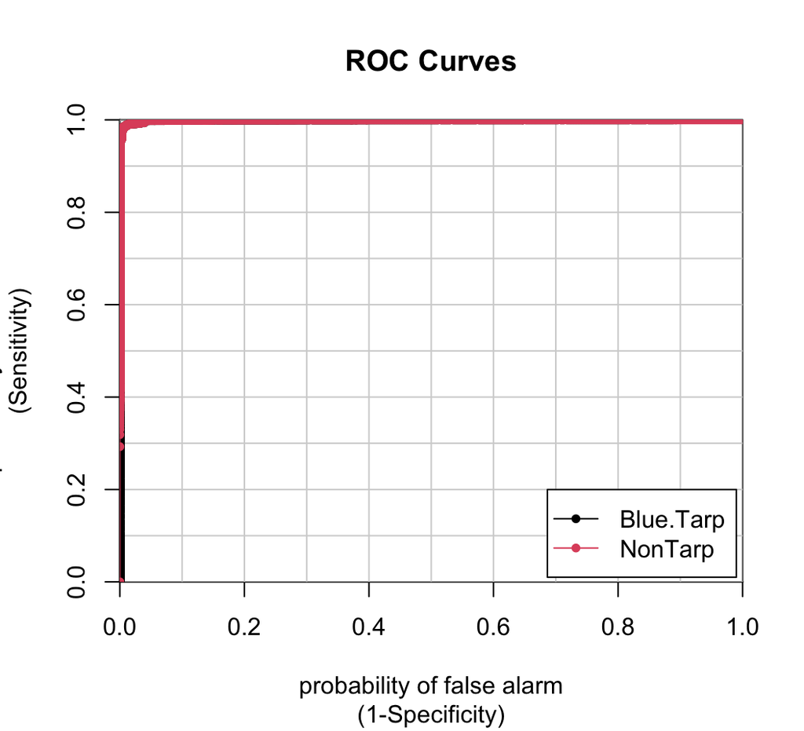

```
#>                       Blue.Tarp   NonTarp
#> Blue.Tarp vs. NonTarp 0.9992589 0.9992589
```

```r
  glm.predictions2 <- predict(glm.fit, haiti_holdout, type="prob")
  colAUC(glm.predictions2, haiti_holdout$binary, plotROC = TRUE)
```

[output not shown]

# Conclusions

## Which algorithm works the best?

[output not shown]

### Do these data seem particularly well-suited to one class of prediction methods, and if so, why?

In module 3.3 of the SYS 6018 course, we compared classification methods K-Nearest Neighbors, Linear Discriminant Analysis, and Quadratic Discriminant Analysis. According to the text, the best performing algorithm will usually be the one whose assumptions best match the data, and that performance will be poor if the model makes assumptions that are not represented in the data. Logistic regression assumes that log-odds (an expression of probability of an event occurring relative to not occurring) of the predictors are useful. KNN offers flexible parameters as it makes no assumptions. LDA and QDA assume that all classes have Gaussian distributions.

The data *seem like* they would be well suited to linear discriminant analysis, because there should be a clear linear boundary between complementary color classes (not quadratic) and they should have Gaussian distributions given their real world frequency. However, we can see below that is not clear from this dataset that all of the predictors have the same covariance.

```r
cov(haiti$Blue,haiti$Green)
```

```
#> [1] 4302.854
```

```r
cov(haiti$Red,haiti$Green)
```

```
#> [1] 5624.511
```

```r
cov(haiti$Red,haiti$Blue)
```

```
#> [1] 4530.342
```

I believe this is the result of unequal representation of red, green, and blue pixels in the imagery, skewed away from blue. This makes it easier to describe the response variable as a binary one, making it a binary classification problem, and either logistic regression or knn are very well suited for that. I believe either method will generally perform very well, but knn might do better with a more diverse dataset, making LR the front-runner.

### Are there additional recommend actions that might be taken to improve results?

One item that crossed my mind at the beginning of the effort is whether binary logistic regression is appropriate given that we have more than just binary data. I understand from online reading that multinomial logistic regression is a technique which can be used for clearer modeling between 3 or more classes. I think this could help us understand other structures a little better. The decision boundary could also be visualized on a plot across all classes (like it was in Module 3), to clearly show how confident we are at each class boundary in any of our methods (that was a powerful tool that I tried to find some code to mimic but it was taking a very long time even to test).

Additionally, dimension reduction techniques like principal components analysis could help with finding even better likelihoods when predicting new observations. I am not as equipped at what to do with the principal components model, i.e., how to plug it back in for testing and interpret the components, but I know we can compute it using the following technique:

```r
set.seed(2)
#http://www.sthda.com/english/articles/37-model-selection-essentials-in-r/152-principal-component-and-partial-least-squares-regression-essentials/
#https://rstudio-pubs-static.s3.amazonaws.com/579414_4aea8984cf1d47abac389fde7eb6d24d.html
library(pls)
pcr.fits <- pcr(Class~., data=haiti.train,scale=TRUE,validation="CV")
```

And this analysis could be repeated in a Bayesian-statistics manner, which I am a lot less qualified to discuss. But given that there is probably a trove of imagery data to draw from given previous emergency relief efforts, we might have “prior probabilities” of the types of objects that we are classifying (soil, for example, should be quite common). Those might be considered by our model. This strikes me as especially important, because disasters of this scale do not occur everyday.

In addition, more GIS data to describe distance (in miles or km) of the false negatives to the nearest true positive would be useful. Since homes tend to be clustered in neighborhoods, this seems possible and it definitely would have improved my ability to estimate “furthest distance between tarps” better for my F-score, turning this into a shortest-path type of problem.